# 1. Exploratory Data Analysis

# New

```python
from scipy.stats import spearmanr
```

```python
data.columns
```

```
Index(['ID', 'Year_Birth', 'Education', 'Marital_Status', 'Income', 'Kidhome',
       'Teenhome', 'Dt_Customer', 'Recency', 'MntWines', 'MntFruits',
       'MntMeatProducts', 'MntFishProducts', 'MntSweetProducts',
       'MntGoldProds', 'NumDealsPurchases', 'NumWebPurchases',
       'NumCatalogPurchases', 'NumStorePurchases', 'NumWebVisitsMonth',
       'AcceptedCmp3', 'AcceptedCmp4', 'AcceptedCmp5', 'AcceptedCmp1',
       'AcceptedCmp2', 'Response', 'Complain', 'Country', 'Age',
       'New_Education', 'New_Marital_Status', 'Dependents',
       'Customer_duration_days', 'TotalCmpAccept', 'TotalProducts',
       'Income_class'],
      dtype='object')
```

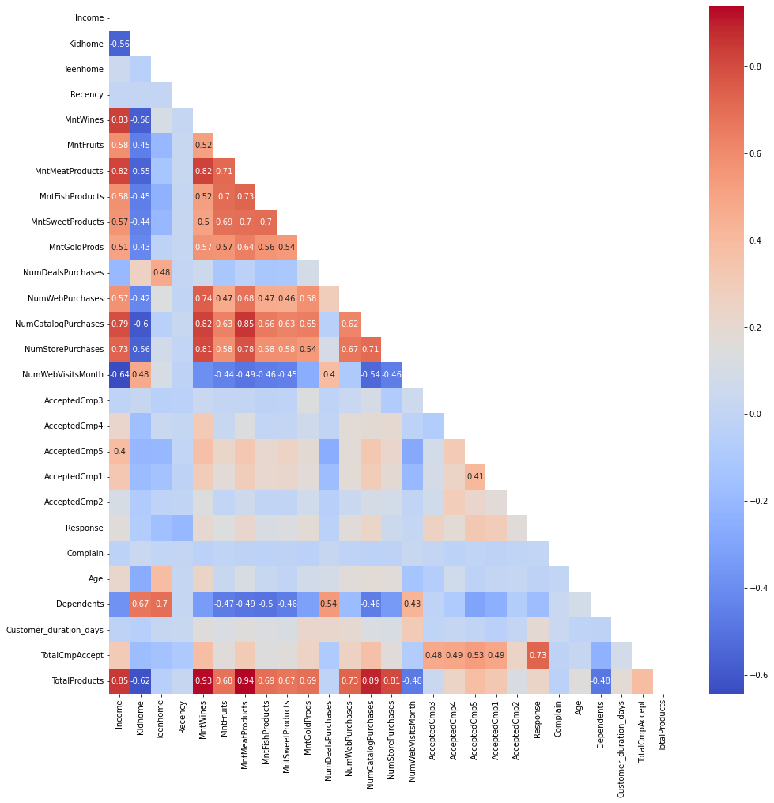

```python
corr = data.drop(['ID', 'Year_Birth'], axis=1).corr(method='spearman')

# Getting the Upper Triangle of the co-relation matrix
matrix = np.triu(corr)
fig, ax = plt.subplots(figsize=(16,16))
ax = sns.heatmap(corr, annot=True, cmap='coolwarm', mask=matrix)
for t in ax.texts:
    if abs(float(t.get_text()))>=0.4:
        t.set_text(t.get_text()) #if the value is greater than 0.4 or less than -0.4 then I set the text
    else:
        t.set_text("") # if not it sets an empty text


plt.show()
```

```python
data.columns
```

```
Index(['ID', 'Year_Birth', 'Education', 'Marital_Status', 'Income', 'Kidhome',
       'Teenhome', 'Dt_Customer', 'Recency', 'MntWines', 'MntFruits',
       'MntMeatProducts', 'MntFishProducts', 'MntSweetProducts',
       'MntGoldProds', 'NumDealsPurchases', 'NumWebPurchases',
       'NumCatalogPurchases', 'NumStorePurchases', 'NumWebVisitsMonth',
       'AcceptedCmp3', 'AcceptedCmp4', 'AcceptedCmp5', 'AcceptedCmp1',
       'AcceptedCmp2', 'Response', 'Complain', 'Country', 'Age',
       'New_Education', 'New_Marital_Status', 'Dependents',
       'Customer_duration_days', 'TotalCmpAccept', 'TotalProducts',
       'Income_class'],
      dtype='object')
```

```python
data.Education.unique()
```

```
array(['Graduation', 'PhD', '2n Cycle', 'Master', 'Basic'], dtype=object)
```

```python
ordinal_vars = ['Education']
edu_level_map = {'Basic':1, 'Graduation':2, 'Master':3, '2nd Cycle':4, 'PhD':5}
data['Education_level'] = data['Education'].map(edu_level_map, na_action='ignore')
data.head()
```

|  | ID | Year_Birth | Education | Marital_Status | Income | Kidhome | Teenhome | Dt_Customer | Recency | MntWines | ... | Country | Age | New_Education | New_Marital_Status | Dependents | Customer_duration_days | TotalCmpAccept | TotalProducts | Income_class | Education_level |
| --- | --- | --- | --- | --- | --- | --- | --- | --- | --- | --- | --- | --- | --- | --- | --- | --- | --- | --- | --- | --- | --- |
| 0 | 1826 | 1970 | Graduation | Divorced | 84835.0 | 0 | 0 | 2014-06-16 | 0 | 189 | ... | SP | 52 | Undergraduate | Divorced | 0 | 2815 | 1 | 1190 | Middle | 2.0 |
| 1 | 1 | 1961 | Graduation | Single | 57091.0 | 0 | 0 | 2014-06-15 | 0 | 464 | ... | CA | 61 | Undergraduate | Single | 0 | 2816 | 2 | 577 | Middle | 2.0 |
| 2 | 10476 | 1958 | Graduation | Married | 67267.0 | 0 | 1 | 2014-05-13 | 0 | 134 | ... | US | 64 | Undergraduate | Married | 1 | 2849 | 0 | 251 | Middle | 2.0 |
| 3 | 1386 | 1967 | Graduation | Together | 32474.0 | 1 | 1 | 2014-05-11 | 0 | 10 | ... | AUS | 55 | Undergraduate | Single | 2 | 2851 | 0 | 11 | Low | 2.0 |
| 4 | 5371 | 1989 | Graduation | Single | 21474.0 | 1 | 0 | 2014-04-08 | 0 | 6 | ... | SP | 33 | Undergraduate | Single | 1 | 2884 | 2 | 91 | Low | 2.0 |

5 rows × 37 columns

```python
data_temp = data.copy()
```

```python
edu_labels = pd.get_dummies(data_temp['Education'], prefix='Edu')
marital_labels = pd.get_dummies(data_temp.Marital_Status, prefix='Marital')
data_temp = pd.concat([data_temp, edu_labels, marital_labels], axis=1)
data_temp.head()
```

|  | ID | Year_Birth | Education | Marital_Status | Income | Kidhome | Teenhome | Dt_Customer | Recency | MntWines | ... | Edu_Master | Edu_PhD | Marital_Absurd | Marital_Alone | Marital_Divorced | Marital_Married | Marital_Single | Marital_Together | Marital_Widow | Marital_YOLO |
| --- | --- | --- | --- | --- | --- | --- | --- | --- | --- | --- | --- | --- | --- | --- | --- | --- | --- | --- | --- | --- | --- |
| 0 | 1826 | 1970 | Graduation | Divorced | 84835.0 | 0 | 0 | 2014-06-16 | 0 | 189 | ... | 0 | 0 | 0 | 0 | 1 | 0 | 0 | 0 | 0 | 0 |
| 1 | 1 | 1961 | Graduation | Single | 57091.0 | 0 | 0 | 2014-06-15 | 0 | 464 | ... | 0 | 0 | 0 | 0 | 0 | 0 | 1 | 0 | 0 | 0 |
| 2 | 10476 | 1958 | Graduation | Married | 67267.0 | 0 | 1 | 2014-05-13 | 0 | 134 | ... | 0 | 0 | 0 | 0 | 0 | 1 | 0 | 0 | 0 | 0 |
| 3 | 1386 | 1967 | Graduation | Together | 32474.0 | 1 | 1 | 2014-05-11 | 0 | 10 | ... | 0 | 0 | 0 | 0 | 0 | 0 | 0 | 1 | 0 | 0 |
| 4 | 5371 | 1989 | Graduation | Single | 21474.0 | 1 | 0 | 2014-04-08 | 0 | 6 | ... | 0 | 0 | 0 | 0 | 0 | 0 | 1 | 0 | 0 | 0 |

5 rows × 50 columns

```python
data_temp.columns
```

```
Index(['ID', 'Year_Birth', 'Education', 'Marital_Status', 'Income', 'Kidhome',
       'Teenhome', 'Dt_Customer', 'Recency', 'MntWines', 'MntFruits',
       'MntMeatProducts', 'MntFishProducts', 'MntSweetProducts',
       'MntGoldProds', 'NumDealsPurchases', 'NumWebPurchases',
       'NumCatalogPurchases', 'NumStorePurchases', 'NumWebVisitsMonth',
       'AcceptedCmp3', 'AcceptedCmp4', 'AcceptedCmp5', 'AcceptedCmp1',
       'AcceptedCmp2', 'Response', 'Complain', 'Country', 'Age',
       'New_Education', 'New_Marital_Status', 'Dependents',
       'Customer_duration_days', 'TotalCmpAccept', 'TotalProducts',
       'Income_class', 'Education_level', 'Edu_2n Cycle', 'Edu_Basic',
       'Edu_Graduation', 'Edu_Master', 'Edu_PhD', 'Marital_Absurd',
       'Marital_Alone', 'Marital_Divorced', 'Marital_Married',
       'Marital_Single', 'Marital_Together', 'Marital_Widow', 'Marital_YOLO'],
      dtype='object')
```

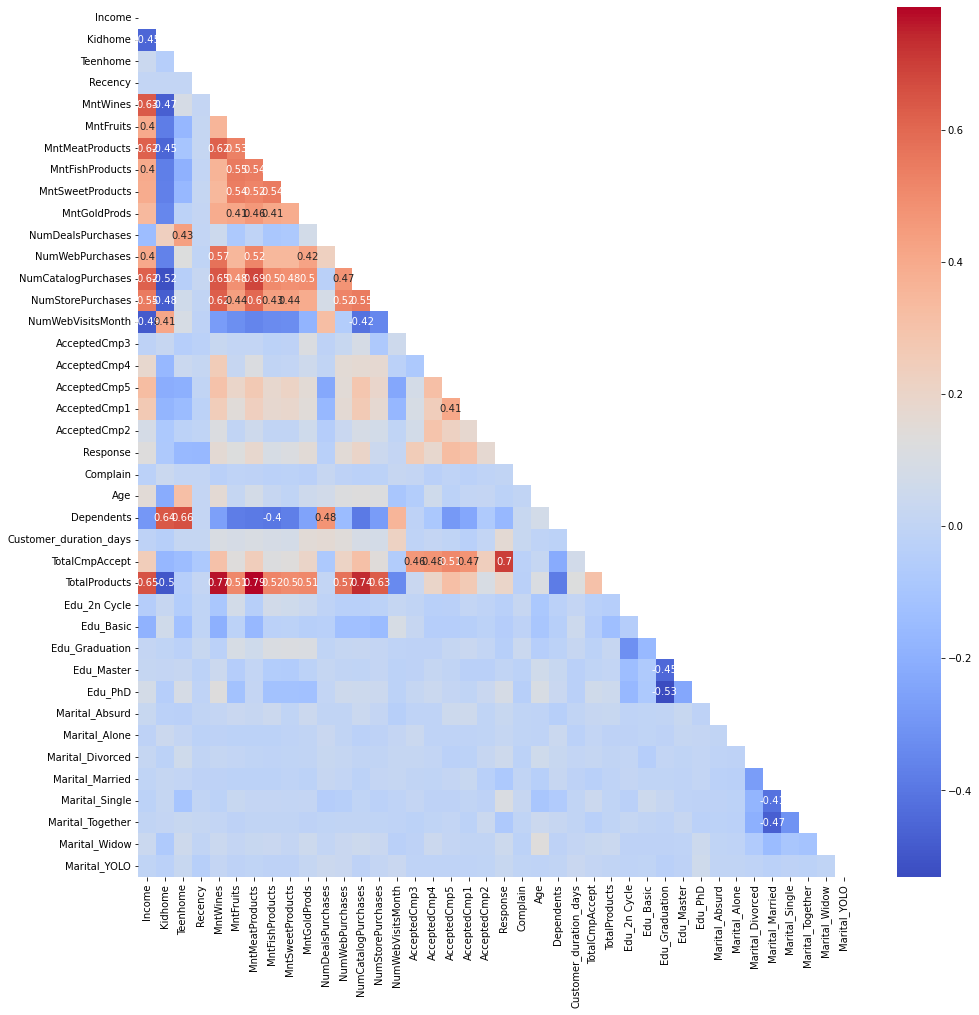

```python
corr = data_temp.drop(['ID', 'Year_Birth', 'Education_level'], axis=1).corr(method='spearman')

# Getting the Upper Triangle of the co-relation matrix
matrix = np.triu(corr)
fig, ax = plt.subplots(figsize=(16,16))
ax = sns.heatmap(corr, annot=True, cmap='coolwarm', mask=matrix)
for t in ax.texts:
    if abs(float(t.get_text()))>=0.4:
        t.set_text(t.get_text()) #if the value is greater than 0.4 or less than -0.4 then I set the text
    else:
        t.set_text("") # if not it sets an empty text


plt.show()
```

# Outlier analysis

```python
orig_data = pd.read_csv('marketing_data.csv')
orig_data.rename(columns = {' Income ': 'Income'}, inplace = True)
orig_data['Income'] = orig_data['Income'].str.replace('$', '')
orig_data['Income'] = orig_data['Income'].str.replace(',', '').astype('float')
orig_data.dropna(inplace=True)
```

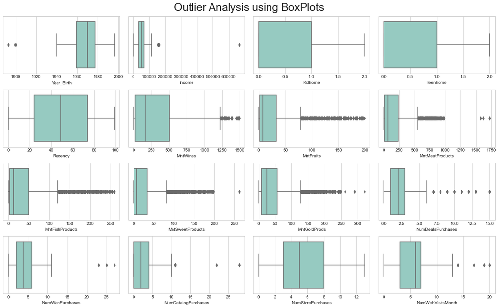

```python
cols_to_check = [c for c in orig_data.columns if (orig_data[c].dtype != 'object') & (orig_data[c].nunique() > 2) & (c != 'ID')]
#cols_to_check.__len__()

fig, ax = plt.subplots(4, 4, figsize = (16, 10))
ax = ax.flatten()

for i, c in enumerate(cols_to_check):
    sns.boxplot(x = orig_data[c], ax = ax[i])
plt.suptitle('Outlier Analysis using BoxPlots', fontsize = 25)
fig.tight_layout()

del cols_to_check
# gc.collect()
```

# Q1

Demographics - Age vs. purchase behaviour Year of joining derived from Dt_Customer Age when joined = Year of joining - Year_birth

*Questions:*

- a) Do young people purchase more on web or in store?
- b) What products do young group people buy more?
- c) What products do older people buy more?

```python
data.describe()
```

|  | ID | Year_Birth | Income | Kidhome | Teenhome | Recency | MntWines | MntFruits | MntMeatProducts | MntFishProducts | ... | AcceptedCmp1 | AcceptedCmp2 | Response | Complain | Age | Dependents | Customer_duration_days | TotalCmpAccept | TotalProducts | Education_level |
| --- | --- | --- | --- | --- | --- | --- | --- | --- | --- | --- | --- | --- | --- | --- | --- | --- | --- | --- | --- | --- | --- |
| count | 2212.000000 | 2212.000000 | 2212.000000 | 2212.000000 | 2212.000000 | 2212.000000 | 2212.000000 | 2212.000000 | 2212.000000 | 2212.000000 | ... | 2212.000000 | 2212.000000 | 2212.000000 | 2212.000000 | 2212.000000 | 2212.000000 | 2212.000000 | 2212.000000 | 2212.000000 | 2014.000000 |
| mean | 5585.160940 | 1968.913653 | 51958.810579 | 0.441682 | 0.505877 | 49.019439 | 305.287523 | 26.329566 | 167.029837 | 37.648734 | ... | 0.064195 | 0.013562 | 0.150542 | 0.009042 | 53.086347 | 0.947559 | 3155.714286 | 0.448915 | 607.268083 | 2.869414 |
| std | 3247.523735 | 11.701599 | 21527.278844 | 0.536955 | 0.544253 | 28.943121 | 337.322940 | 39.744052 | 224.254493 | 54.772033 | ... | 0.245156 | 0.115691 | 0.357683 | 0.094678 | 11.701599 | 0.749466 | 202.494886 | 0.893017 | 602.513364 | 1.264097 |
| min | 0.000000 | 1940.000000 | 1730.000000 | 0.000000 | 0.000000 | 0.000000 | 0.000000 | 0.000000 | 0.000000 | 0.000000 | ... | 0.000000 | 0.000000 | 0.000000 | 0.000000 | 26.000000 | 0.000000 | 2802.000000 | 0.000000 | 5.000000 | 1.000000 |
| 25% | 2814.750000 | 1959.000000 | 35233.500000 | 0.000000 | 0.000000 | 24.000000 | 24.000000 | 2.000000 | 16.000000 | 3.000000 | ... | 0.000000 | 0.000000 | 0.000000 | 0.000000 | 45.000000 | 0.000000 | 2982.000000 | 0.000000 | 69.000000 | 2.000000 |
| 50% | 5454.500000 | 1970.000000 | 51371.000000 | 0.000000 | 0.000000 | 49.000000 | 175.500000 | 8.000000 | 68.000000 | 12.000000 | ... | 0.000000 | 0.000000 | 0.000000 | 0.000000 | 52.000000 | 1.000000 | 3158.000000 | 0.000000 | 397.000000 | 2.000000 |
| 75% | 8418.500000 | 1977.000000 | 68487.000000 | 1.000000 | 1.000000 | 74.000000 | 505.000000 | 33.000000 | 232.250000 | 50.000000 | ... | 0.000000 | 0.000000 | 0.000000 | 0.000000 | 63.000000 | 1.000000 | 3331.000000 | 1.000000 | 1048.000000 | 3.000000 |
| max | 11191.000000 | 1996.000000 | 162397.000000 | 2.000000 | 2.000000 | 99.000000 | 1493.000000 | 199.000000 | 1725.000000 | 259.000000 | ... | 1.000000 | 1.000000 | 1.000000 | 1.000000 | 82.000000 | 3.000000 | 3501.000000 | 5.000000 | 2525.000000 | 5.000000 |

8 rows × 30 columns

```python
data.head()
```

|  | ID | Year_Birth | Education | Marital_Status | Income | Kidhome | Teenhome | Dt_Customer | Recency | MntWines | ... | Country | Age | New_Education | New_Marital_Status | Dependents | Customer_duration_days | TotalCmpAccept | TotalProducts | Income_class | Education_level |
| --- | --- | --- | --- | --- | --- | --- | --- | --- | --- | --- | --- | --- | --- | --- | --- | --- | --- | --- | --- | --- | --- |
| 0 | 1826 | 1970 | Graduation | Divorced | 84835.0 | 0 | 0 | 2014-06-16 | 0 | 189 | ... | SP | 52 | Undergraduate | Divorced | 0 | 2815 | 1 | 1190 | Middle | 2.0 |
| 1 | 1 | 1961 | Graduation | Single | 57091.0 | 0 | 0 | 2014-06-15 | 0 | 464 | ... | CA | 61 | Undergraduate | Single | 0 | 2816 | 2 | 577 | Middle | 2.0 |
| 2 | 10476 | 1958 | Graduation | Married | 67267.0 | 0 | 1 | 2014-05-13 | 0 | 134 | ... | US | 64 | Undergraduate | Married | 1 | 2849 | 0 | 251 | Middle | 2.0 |
| 3 | 1386 | 1967 | Graduation | Together | 32474.0 | 1 | 1 | 2014-05-11 | 0 | 10 | ... | AUS | 55 | Undergraduate | Single | 2 | 2851 | 0 | 11 | Low | 2.0 |
| 4 | 5371 | 1989 | Graduation | Single | 21474.0 | 1 | 0 | 2014-04-08 | 0 | 6 | ... | SP | 33 | Undergraduate | Single | 1 | 2884 | 2 | 91 | Low | 2.0 |

5 rows × 37 columns

```python
data.columns
```

```
Index(['ID', 'Year_Birth', 'Education', 'Marital_Status', 'Income', 'Kidhome',
       'Teenhome', 'Dt_Customer', 'Recency', 'MntWines', 'MntFruits',
       'MntMeatProducts', 'MntFishProducts', 'MntSweetProducts',
       'MntGoldProds', 'NumDealsPurchases', 'NumWebPurchases',
       'NumCatalogPurchases', 'NumStorePurchases', 'NumWebVisitsMonth',
       'AcceptedCmp3', 'AcceptedCmp4', 'AcceptedCmp5', 'AcceptedCmp1',
       'AcceptedCmp2', 'Response', 'Complain', 'Country', 'Age',
       'New_Education', 'New_Marital_Status', 'Dependents',
       'Customer_duration_days', 'TotalCmpAccept', 'TotalProducts',
       'Income_class', 'Education_level'],
      dtype='object')
```

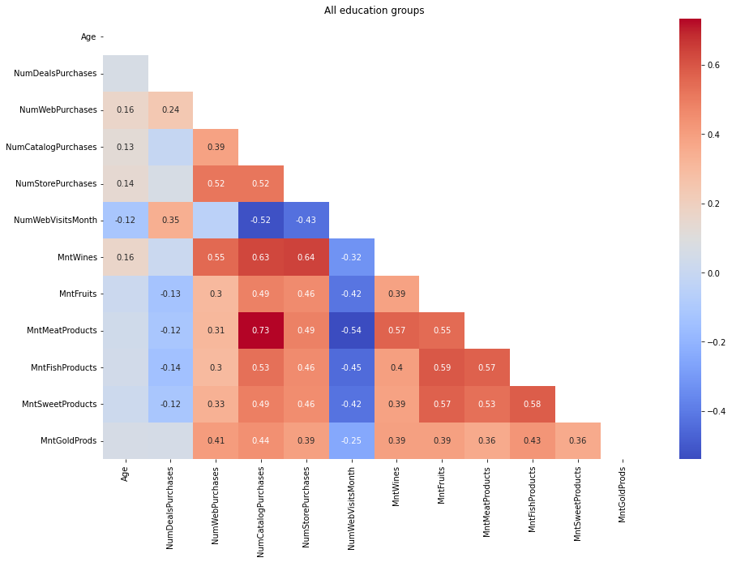

```python
fig = plt.figure(figsize=(15,10))

age_mode_vars = ['ID', 'Age', 'NumDealsPurchases', 'NumWebPurchases', 'NumCatalogPurchases',
                    'NumStorePurchases', 'NumWebVisitsMonth', 'MntWines', 'MntFruits',
                    'MntMeatProducts', 'MntFishProducts', 'MntSweetProducts', 'MntGoldProds']
age_mode_data = data[age_mode_vars]
age_mode_corr = age_mode_data.drop('ID', axis=1).corr()

matrix = np.triu(age_mode_corr) # upper triangular corelation matrix
ax = sns.heatmap(age_mode_corr, annot=True, cmap='coolwarm', mask=matrix)
for t in ax.texts:
    if abs(float(t.get_text()))>=0.1:
        t.set_text(t.get_text()) #if the value is greater than 0.4 or less than -0.4 then make the value visible
    else:
        t.set_text("") # if not it sets an empty text

plt.title("All education groups")
plt.show()
```

```python
data.Education.unique()
```

```
array(['Graduation', 'PhD', '2n Cycle', 'Master', 'Basic'], dtype=object)
```

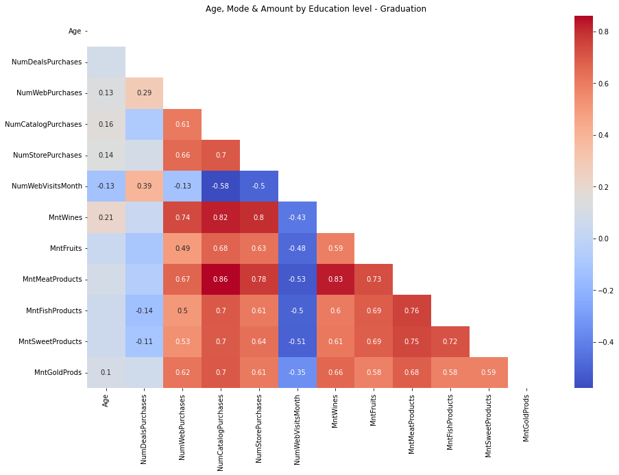

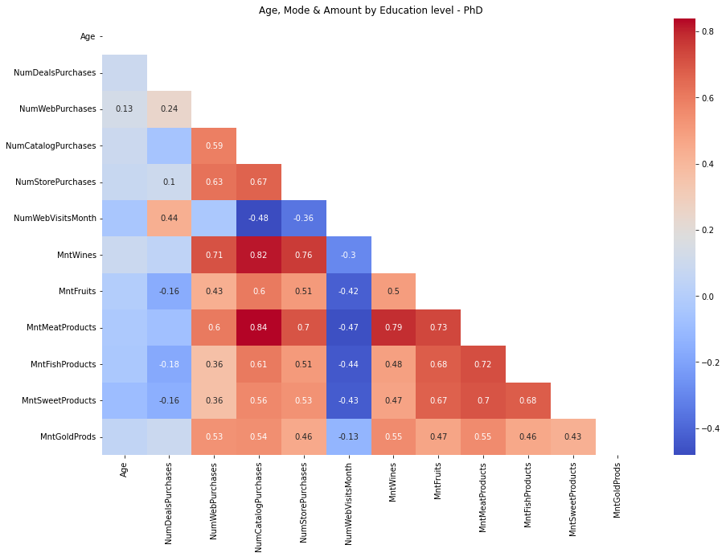

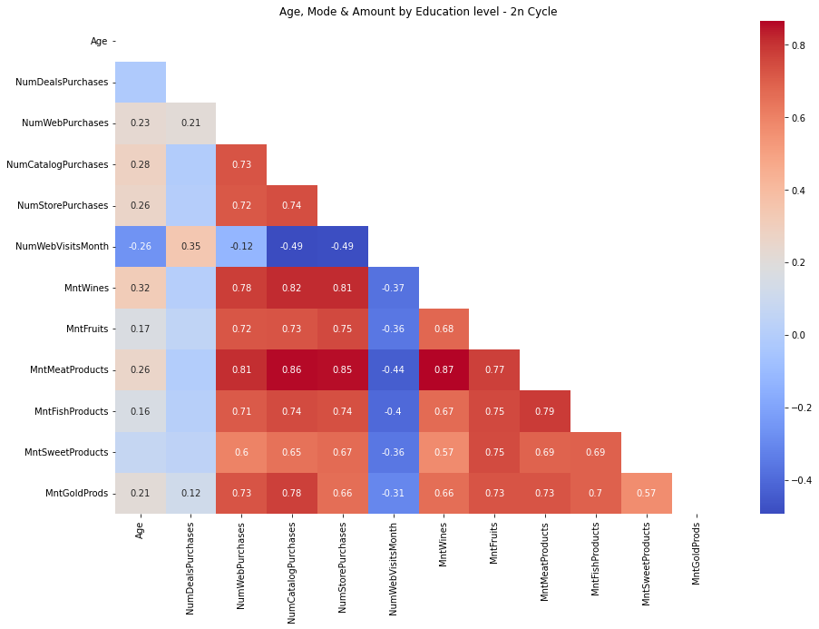

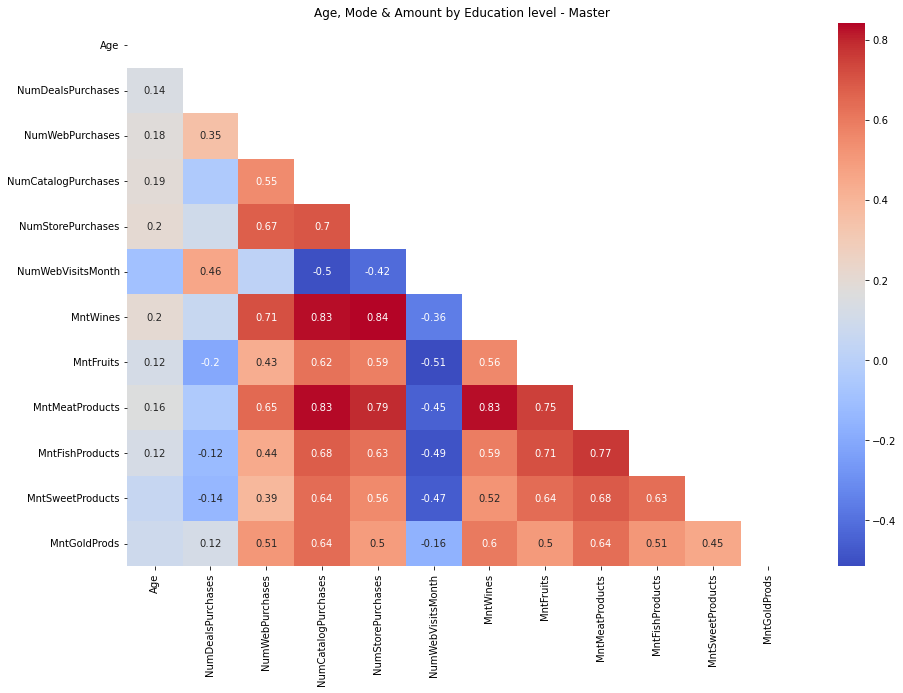

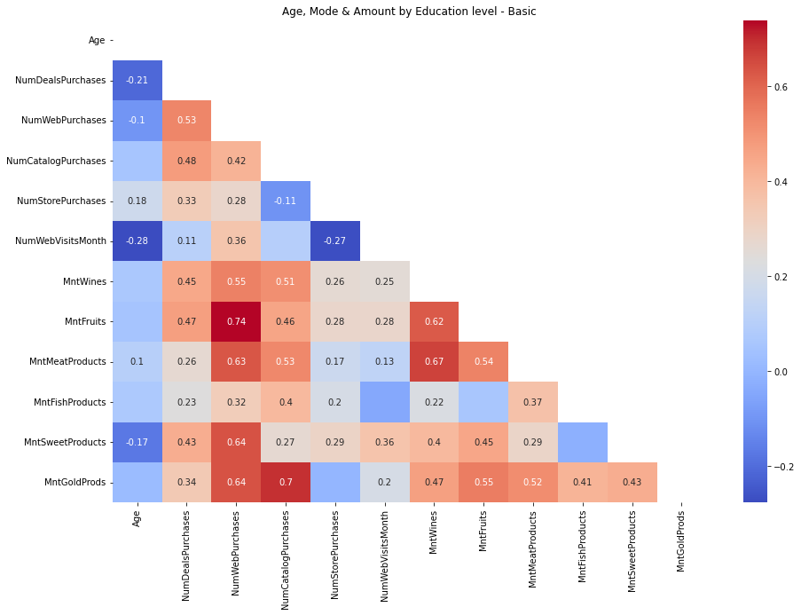

```python
age_mode_vars = ['ID', 'Age', 'NumDealsPurchases', 'NumWebPurchases', 'NumCatalogPurchases',
                    'NumStorePurchases', 'NumWebVisitsMonth', 'MntWines', 'MntFruits',
                    'MntMeatProducts', 'MntFishProducts', 'MntSweetProducts', 'MntGoldProds']

for edu in data.Education.unique():

    fig = plt.figure(figsize=(15,10))
    age_mode_data = data[data.Education == edu][age_mode_vars]
    age_mode_corr = age_mode_data.drop('ID', axis=1).corr(method='spearman')

    matrix = np.triu(age_mode_corr) # upper triangular corelation matrix
    ax = sns.heatmap(age_mode_corr, annot=True, cmap='coolwarm', mask=matrix)
    for t in ax.texts:
        if abs(float(t.get_text()))>=0.1:
            t.set_text(t.get_text()) #if the value is greater than 0.4 or less than -0.4 then make the value visible
        else:
            t.set_text("") # if not it sets an empty text

    plt.title(f"Age, Mode & Amount by Education level - {edu}")
    plt.show()
```

# Q2

Kids and Teens at home Vs. Purchase behaviour

*Questions:*

- a) What products do people with kids at home purchase more?
- b) What products do people with teens at home purchase more?
- c) Difference between people with kids/teens at home vs. people without them with respect to purchase behaviour

```python
data.columns
```

```
Index(['ID', 'Year_Birth', 'Education', 'Marital_Status', 'Income', 'Kidhome',
       'Teenhome', 'Dt_Customer', 'Recency', 'MntWines', 'MntFruits',
       'MntMeatProducts', 'MntFishProducts', 'MntSweetProducts',
       'MntGoldProds', 'NumDealsPurchases', 'NumWebPurchases',
       'NumCatalogPurchases', 'NumStorePurchases', 'NumWebVisitsMonth',
       'AcceptedCmp3', 'AcceptedCmp4', 'AcceptedCmp5', 'AcceptedCmp1',
       'AcceptedCmp2', 'Response', 'Complain', 'Country', 'Age',
       'New_Education', 'New_Marital_Status', 'Dependents',
       'Customer_duration_days', 'TotalCmpAccept', 'TotalProducts',
       'Income_class', 'Education_level'],
      dtype='object')
```

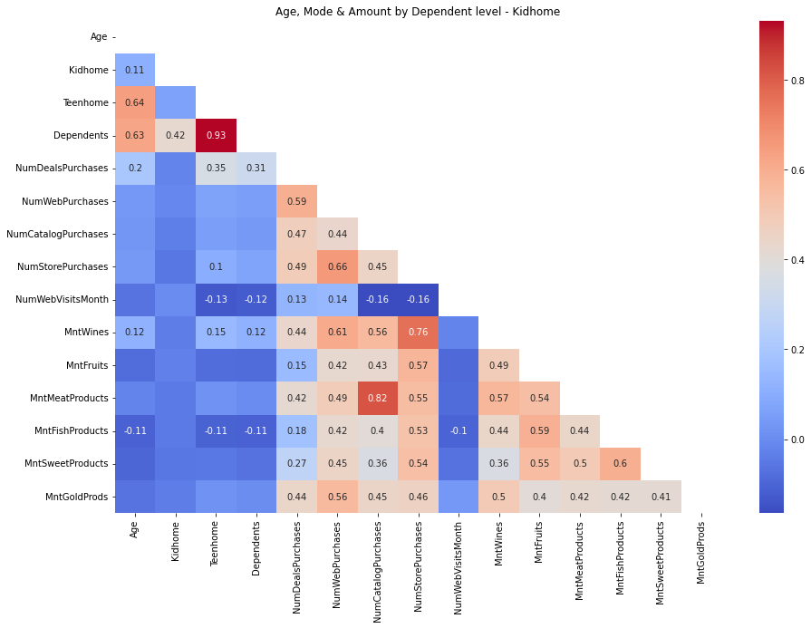

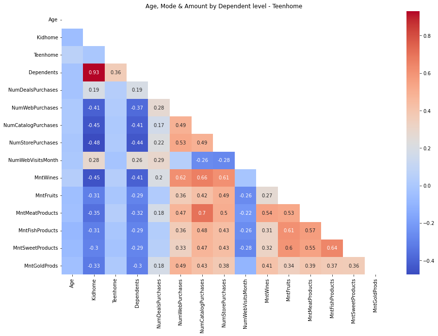

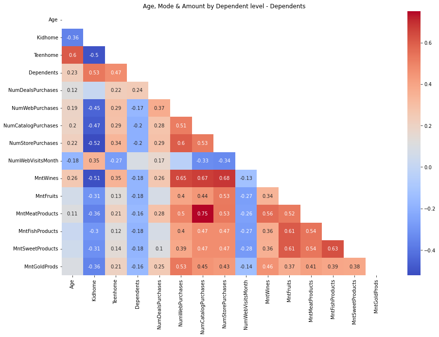

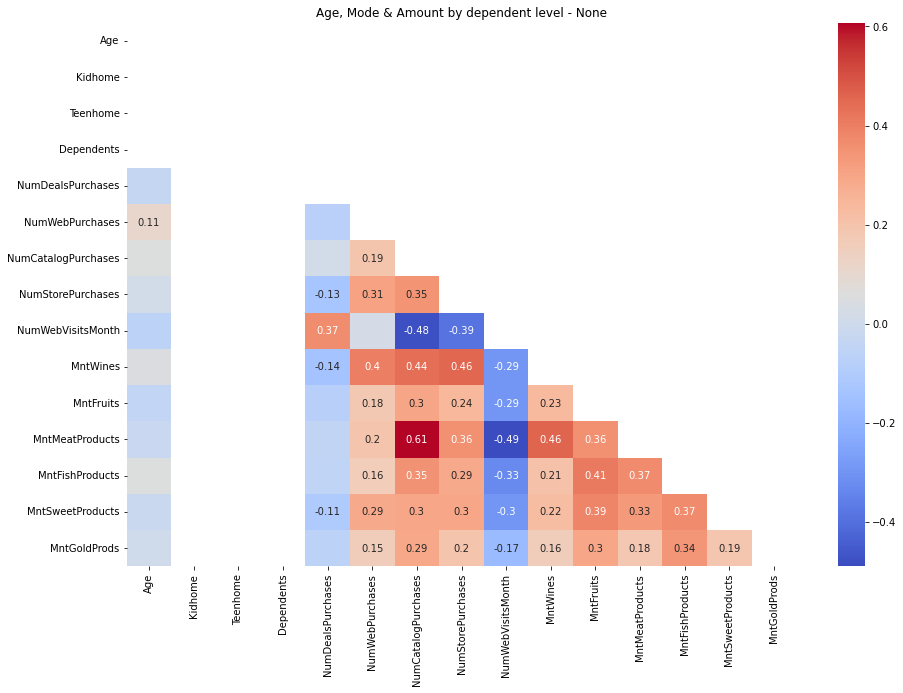

```python
kids_teen_vars = ['ID', 'Age','Kidhome', 'Teenhome', 'Dependents', 'NumDealsPurchases', 'NumWebPurchases',
                    'NumCatalogPurchases', 'NumStorePurchases', 'NumWebVisitsMonth', 'MntWines', 'MntFruits',
                    'MntMeatProducts', 'MntFishProducts', 'MntSweetProducts', 'MntGoldProds']

vars = ['Kidhome', 'Teenhome', 'Dependents']
for var in vars:

    fig = plt.figure(figsize=(15,10))
    kids_teen_data = data[data[var] > 0][kids_teen_vars]
    kids_teen_corr = kids_teen_data.drop('ID', axis=1).corr()

    matrix = np.triu(kids_teen_corr) # upper triangular corelation matrix
    ax = sns.heatmap(kids_teen_corr, annot=True, cmap='coolwarm', mask=matrix)
    for t in ax.texts:
        if abs(float(t.get_text()))>=0.1:
            t.set_text(t.get_text()) #if the value is greater than 0.4 or less than -0.4 then make the value visible
        else:
            t.set_text("") # if not it sets an empty text

    plt.title(f"Age, Mode & Amount by Dependent level - {var}")
    plt.show()

fig = plt.figure(figsize=(15,10))
kids_teen_data = data[data.Dependents == 0][kids_teen_vars]
kids_teen_corr = kids_teen_data.drop('ID', axis=1).corr()

matrix = np.triu(kids_teen_corr) # upper triangular corelation matrix
ax = sns.heatmap(kids_teen_corr, annot=True, cmap='coolwarm', mask=matrix)
for t in ax.texts:
    if abs(float(t.get_text()))>=0.1:
        t.set_text(t.get_text()) #if the value is greater than 0.4 or less than -0.4 then make the value visible
    else:
        t.set_text("") # if not it sets an empty text

plt.title("Age, Mode & Amount by dependent level - None")
plt.show()
```

# Q3

Product type vs. Purchase channel Product type - Wine, Fruits, Meat, Sweet, Gold Purchase type - Deals, Web, Catalog, Store

*Questions:*

- a) Wine is purchased through which channel more?

  > ...and other similar questions based on the above categories

### Q3 may not be possible since we dont know which channel the customer used to make a particular purchase

```python
data.columns
```

```
Index(['ID', 'Year_Birth', 'Education', 'Marital_Status', 'Income', 'Kidhome',
       'Teenhome', 'Dt_Customer', 'Recency', 'MntWines', 'MntFruits',
       'MntMeatProducts', 'MntFishProducts', 'MntSweetProducts',
       'MntGoldProds', 'NumDealsPurchases', 'NumWebPurchases',
       'NumCatalogPurchases', 'NumStorePurchases', 'NumWebVisitsMonth',
       'AcceptedCmp3', 'AcceptedCmp4', 'AcceptedCmp5', 'AcceptedCmp1',
       'AcceptedCmp2', 'Response', 'Complain', 'Country', 'Age',
       'New_Education', 'New_Marital_Status', 'Dependents',
       'Customer_duration_days', 'TotalCmpAccept', 'TotalProducts',
       'Income_class', 'Education_level'],
      dtype='object')
```

```python
items = ['MntWines', 'MntFruits', 'MntMeatProducts',
        'MntFishProducts', 'MntSweetProducts', 'MntGoldProds']

channels = ['NumDealsPurchases', 'NumWebPurchases', 'NumCatalogPurchases',
            'NumStorePurchases', 'NumWebVisitsMonth']

campaigns = ['AcceptedCmp1', 'AcceptedCmp2', 'AcceptedCmp3',
            'AcceptedCmp4', 'AcceptedCmp5']
```

# Q4

Combine 2 and 3 Identify the default behaviour. i.e, Say for example people without kids purchase wine from stores. Does this behviour change when they have kids. LIke they buy when there are deals or through web channel.

Frame and answer questions

> Since Q3 is not possible, we cannot answer Q4 either

# Q5

Marital status vs. Purchase behaviour

*Question:*

- a) Which channel (Deals, Store, Web, etc.) do married people prefer?
- b) Which products do single people buy more?

```python
data.columns
```

```
Index(['ID', 'Year_Birth', 'Education', 'Marital_Status', 'Income', 'Kidhome',
       'Teenhome', 'Dt_Customer', 'Recency', 'MntWines', 'MntFruits',
       'MntMeatProducts', 'MntFishProducts', 'MntSweetProducts',
       'MntGoldProds', 'NumDealsPurchases', 'NumWebPurchases',
       'NumCatalogPurchases', 'NumStorePurchases', 'NumWebVisitsMonth',
       'AcceptedCmp3', 'AcceptedCmp4', 'AcceptedCmp5', 'AcceptedCmp1',
       'AcceptedCmp2', 'Response', 'Complain', 'Country', 'Age',
       'New_Education', 'New_Marital_Status', 'Dependents',
       'Customer_duration_days', 'TotalCmpAccept', 'TotalProducts',
       'Income_class', 'Education_level'],
      dtype='object')
```

```python
data.New_Marital_Status.unique()
```

```
array(['Divorced', 'Single', 'Married', 'Widow'], dtype=object)
```

```python
dd = data[data.New_Marital_Status == 'Divorced'][channels].sum()
dd
```

```
NumDealsPurchases       564
NumWebPurchases         998
NumCatalogPurchases     619
NumStorePurchases      1348
NumWebVisitsMonth      1268
dtype: int64
```

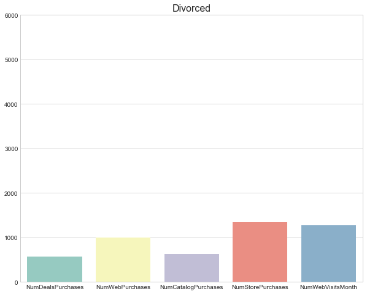

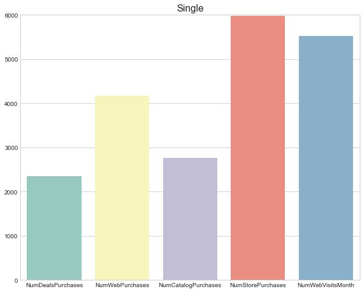

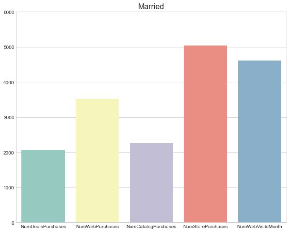

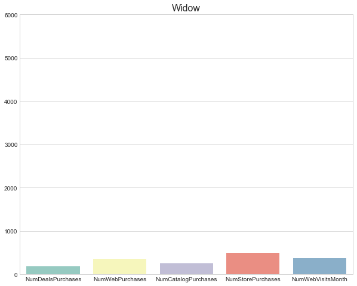

```python
for status in data.New_Marital_Status.unique():
    fig = plt.figure(figsize=(10,8))

    temp = data[data.New_Marital_Status == status]
    y = temp[channels].sum()
    # plt.plot(y = data[data.New_Marital_Status == 'Single'][channels])
    sns.barplot(x=channels, y=y)
    plt.ylim(0, 6000)
    plt.title(status)
    plt.show()
```

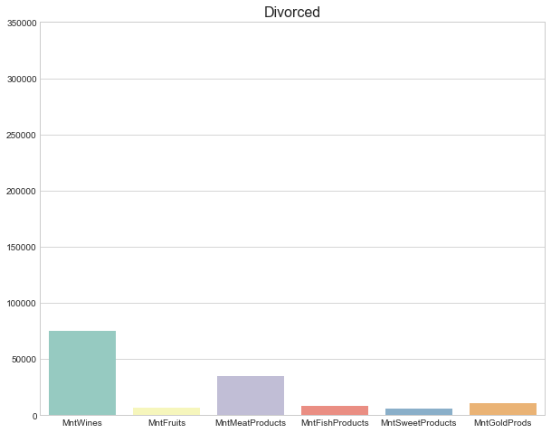

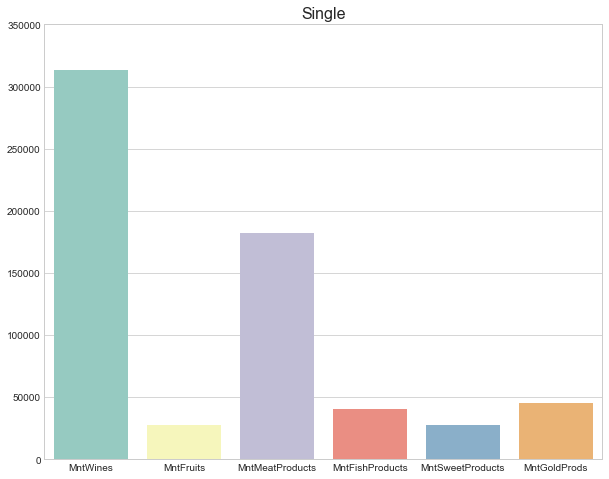

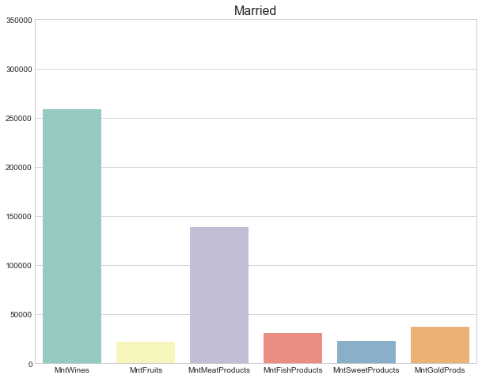

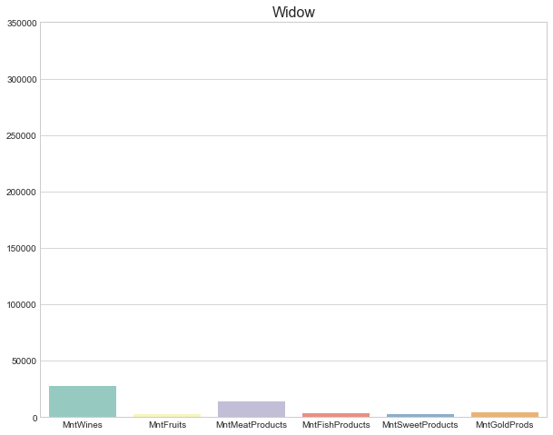

```python
for status in data.New_Marital_Status.unique():
    fig = plt.figure(figsize=(10,8))

    temp = data[data.New_Marital_Status == status]
    y = temp[items].sum()
    # plt.plot(y = data[data.New_Marital_Status == 'Single'][channels])
    sns.barplot(x=items, y=y)
    plt.ylim(0, 350000)
    plt.title(status)
    plt.show()
```

```python
# plt.figure(figsize = (20, 15))
# sns.boxplot(data = data, x = channels, y=data[data[channels]], hue='New_Marital_Status')
#     # plt.ylim(5, 80)
#     # plt.title('Country Vs Customer Age Per Education')
```

```python
# ax = (
#     data.set_index('New_Marital_Status', append=True)  # set E as part of the index
#       .stack()                      # pull A - D into rows
#       .to_frame()                   # convert to a dataframe
#       .reset_index()                # make the index into reg. columns
#     #   .rename(columns={'level_2': 'quantity', 0: 'value'})  # rename columns
#     #   .drop('level_0', axis='columns')   # drop junk columns
#       .pipe((sns.boxplot, 'data'), x='quantity', y='value', hue='E', hue_order=[1, 2])
# )
# sns.despine(trim=True)
```

# Q6

Education vs. Purchase behaviour

*Question:*

- a) Which channel (Deals, Store, Web, etc.) do people with basic education prefer?
- b) Which products do people with Masters degree buy more?

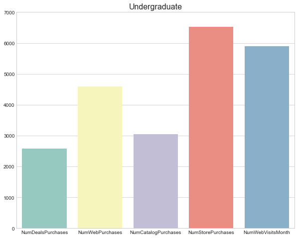

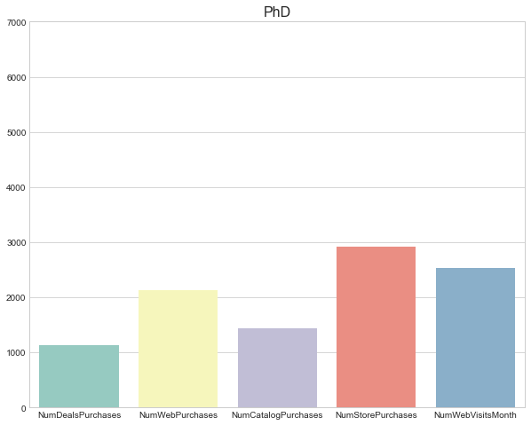

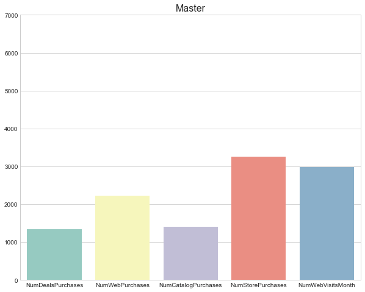

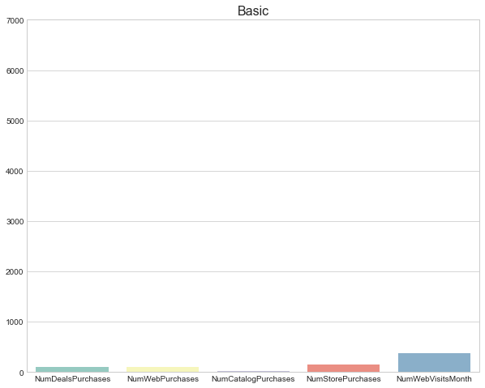

```python
for level in data.New_Education.unique():
    fig = plt.figure(figsize=(10,8))

    temp = data[data.New_Education == level]
    y = temp[channels].sum()
    # plt.plot(y = data[data.New_Education == 'Single'][channels])
    sns.barplot(x=channels, y=y)
    plt.ylim(0, 7000)
    plt.title(level)
    plt.show()
```

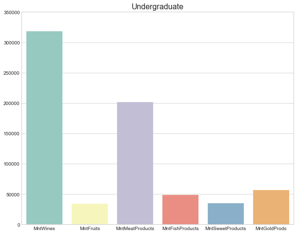

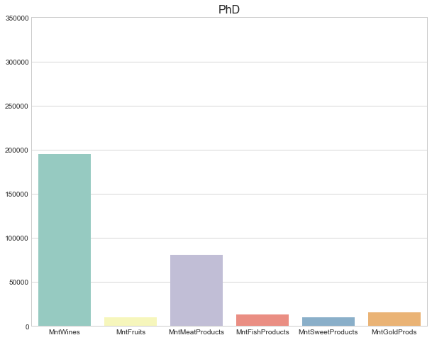

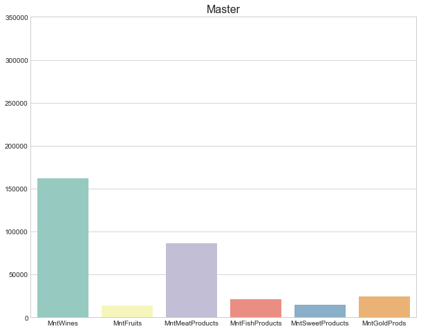

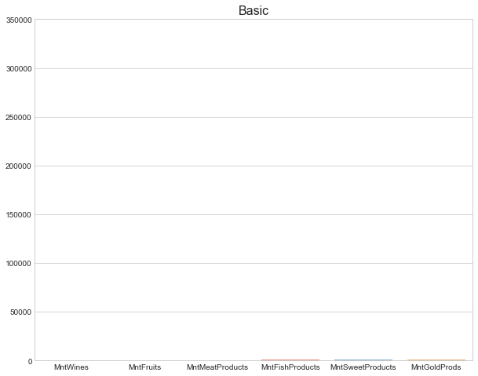

```python
for level in data.New_Education.unique():
    fig = plt.figure(figsize=(10,8))

    temp = data[data.New_Education == level]
    y = temp[items].sum()
    # plt.plot(y = data[data.New_Education == 'Single'][channels])
    sns.barplot(x=items, y=y)
    plt.ylim(0, 350000)
    plt.title(level)
    plt.show()
```

# Q7

Income vs. Country

*Question:*

- a) Which country do high income people come from?
- b) Which products do low income people buy more?

```python
data.columns
```

```
Index(['ID', 'Year_Birth', 'Education', 'Marital_Status', 'Income', 'Kidhome',
       'Teenhome', 'Dt_Customer', 'Recency', 'MntWines', 'MntFruits',
       'MntMeatProducts', 'MntFishProducts', 'MntSweetProducts',
       'MntGoldProds', 'NumDealsPurchases', 'NumWebPurchases',
       'NumCatalogPurchases', 'NumStorePurchases', 'NumWebVisitsMonth',
       'AcceptedCmp3', 'AcceptedCmp4', 'AcceptedCmp5', 'AcceptedCmp1',
       'AcceptedCmp2', 'Response', 'Complain', 'Country', 'Age',
       'New_Education', 'New_Marital_Status', 'Dependents',
       'Customer_duration_days', 'TotalCmpAccept', 'TotalProducts',
       'Income_class', 'Education_level'],
      dtype='object')
```

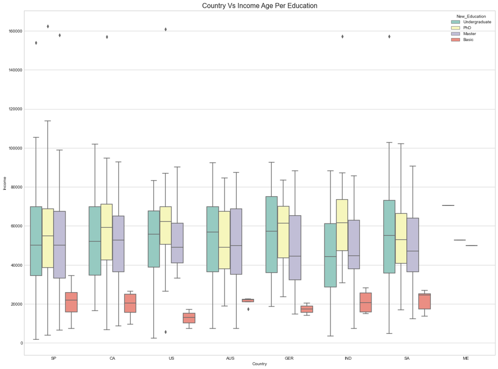

```python
# for level in data.Income.unique():
#     fig = plt.figure(figsize=(10,8))

#     temp = data[data.New_Education == level]
#     y = temp[channels].sum()
#     # plt.plot(y = data[data.New_Education == 'Single'][channels])
#     sns.barplot(x=channels, y=y)
#     plt.ylim(0, 7000)
#     plt.title(level)
#     plt.show()

plt.figure(figsize = (20, 15))
sns.boxplot(data = data, x = 'Country', y = 'Income', hue = 'New_Education')
# plt.ylim(5, 80)
plt.title('Country Vs Income Age Per Education');
```

# StorePurchases vs. dependents

```python
data.columns
```

```
Index(['ID', 'Year_Birth', 'Education', 'Marital_Status', 'Income', 'Kidhome',
       'Teenhome', 'Dt_Customer', 'Recency', 'MntWines', 'MntFruits',
       'MntMeatProducts', 'MntFishProducts', 'MntSweetProducts',
       'MntGoldProds', 'NumDealsPurchases', 'NumWebPurchases',
       'NumCatalogPurchases', 'NumStorePurchases', 'NumWebVisitsMonth',
       'AcceptedCmp3', 'AcceptedCmp4', 'AcceptedCmp5', 'AcceptedCmp1',
       'AcceptedCmp2', 'Response', 'Complain', 'Country', 'Age',
       'New_Education', 'New_Marital_Status', 'Dependents',
       'Customer_duration_days', 'TotalCmpAccept', 'TotalProducts',
       'Income_class', 'Education_level'],
      dtype='object')
```

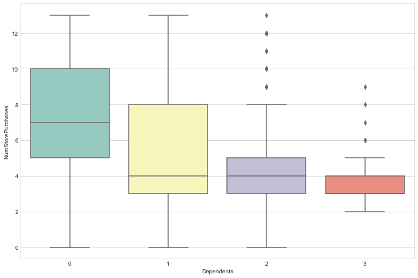

```python
sns.boxplot(data = data, y = 'NumStorePurchases', x = 'Dependents');
```

# CLUSTERING

```python
from sklearn.cluster import KMeans
from sklearn.preprocessing import StandardScaler, normalize
from sklearn.metrics import silhouette_score
```

```python
data.columns
```

```
Index(['ID', 'Year_Birth', 'Education', 'Marital_Status', 'Income', 'Kidhome',
       'Teenhome', 'Dt_Customer', 'Recency', 'MntWines', 'MntFruits',
       'MntMeatProducts', 'MntFishProducts', 'MntSweetProducts',
       'MntGoldProds', 'NumDealsPurchases', 'NumWebPurchases',
       'NumCatalogPurchases', 'NumStorePurchases', 'NumWebVisitsMonth',
       'AcceptedCmp3', 'AcceptedCmp4', 'AcceptedCmp5', 'AcceptedCmp1',
       'AcceptedCmp2', 'Response', 'Complain', 'Country', 'Age',
       'New_Education', 'New_Marital_Status', 'Dependents',
       'Customer_duration_days', 'TotalCmpAccept', 'TotalProducts',
       'Income_class', 'Education_level'],
      dtype='object')
```

```python
cluster_cols = ['Age', 'NumDealsPurchases', 'NumWebPurchases',
       'NumCatalogPurchases', 'NumStorePurchases', 'NumWebVisitsMonth',
       'MntWines', 'MntFruits',
       'MntMeatProducts', 'MntFishProducts', 'MntSweetProducts',
       'MntGoldProds', 'Recency', 'Income', 'Dependents', 'TotalProducts']
cluster_data = normalize(data.loc[:, cluster_cols])
```

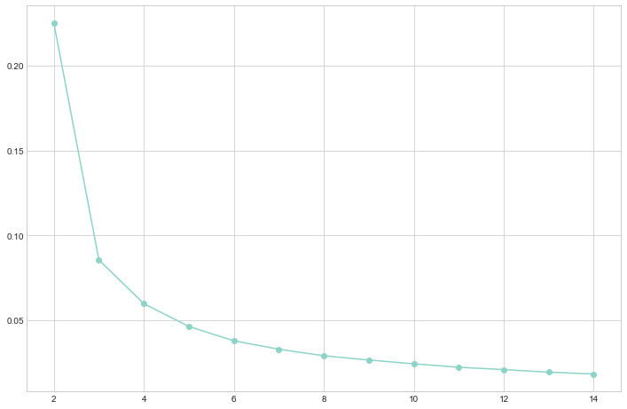

```python
cluster_range = [2,3,4,5,6,7,8,9,10,11,12,13,14]
inertias = []

for c in cluster_range:
    kmeans = KMeans(n_clusters=c).fit(cluster_data)
    inertias.append(kmeans.inertia_)

plt.figure()
plt.plot(cluster_range, inertias, marker='o')
plt.show()
```

We can consider to use either 3 or even 4 clusters. Maybe even upto 6.

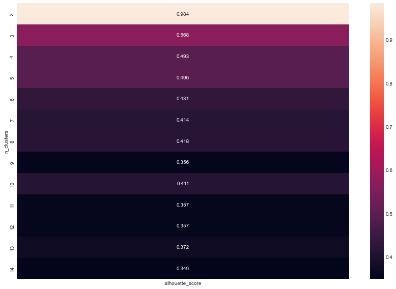

```python
# calculating silhouette scores
from sklearn.metrics import silhouette_samples, silhouette_score

results = []
for c in cluster_range:
    clusterer = KMeans(n_clusters=c)
    cluster_labels = clusterer.fit_predict(cluster_data)
    silhouetter_avg = silhouette_score(cluster_data, cluster_labels)
    results.append([c, silhouetter_avg])

result = pd.DataFrame(results, columns=['n_clusters', 'silhouette_score'])
pivot_km = pd.pivot_table(result, index='n_clusters', values='silhouette_score')

plt.figure()
sns.heatmap(pivot_km, annot=True, fmt='.3f', cmap=sns.cm._rocket_lut)
plt.tight_layout()
```

We can see that the silhouette score does not change greatly from 4 to 5 clusters. Thus, we minimilastically choose **4 clusters.**